[figure not shown]

1 导言

有些图像难以想象，故画图辅助理解

1.1 三叶玫瑰线

θ=180.00

°

代码：

t = linspace(0, pi, 1000); % 将（0~pi）1000等分

r = cos(3*t);

x = r .* cos(t); y = r .* sin(t);

h1 = plot(x(1), y(1)); hold on;

1

Mathematical Experiments by Matlab!

by Zebang Li!

2015

[figure not shown]

h2 = plot(x(1), y(1), ’o’);

axis([-1 1.2 -1 1]);

for i = 10 : 10: 1000

set(h1, ’xdata’, x(1:i), ’ydata’, y(1:i));

set(h2, ’xdata’, x(i), ’ydata’, y(i));

drawnow; pause(0.03);

end

1.2 摆线

2

代码：

t = linspace(0,4*pi, 1000);

X = t - sin(t); Y = 1 - cos(t);

h1 = plot(X(1), Y(1)); hold on;

h2 = plot(X(1), Y(1), ’o’);

axis([0 4*pi -2 3]);

for i= 10 : 10 : 1000

set(h1, ’xdata’, X(1:i), ’ydata’, Y(1:i));

set(h2, ’xdata’, X(i), ’ydata’, Y(i));

drawnow; pause(0.05);

end

3

[figure not shown]

1.3 螺旋线

代码：

Z = linspace(0,10*pi,1000);

X = sin(Z); Y = cos(Z);

h1 = plot3(X(1), Y(1), Z(1)); hold on;

h2 = plot3(X(1), Y(1), Z(1), ’o’);

axis([-1 1 -1 1 0 40]);

for i = 10 : 10 : 1000

set(h1, ’xdata’, X(1:i), ’ydata’, Y(1:i), ’zdata’, Z(1:i));

4

[figure not shown]

set(h2, ’xdata’, X(i), ’ydata’, Y(i), ’zdata’, Z(i));

drawnow; pause(0.02);

end

1.4 摆线的形成

代码：

% 画底

plot([-2 15],[0 0]); hold on;

5

% 画圆

t = linspace(0,2*pi,10000);

X1 = cos(t); Y1 = 1 + sin(t);

h1 = plot(X1, Y1);

% 画摆线

t = linspace(0,4*pi,10000);

X2 = t - sin(t); Y2 = 1 - cos(t);

h2 = plot(X2(1),Y2(1));

h3 = plot(X2(1),Y2(1),’o’);

% 连接圆心和点

h4 = plot([0 0],[1 0]);

axis([-2 15 -5 8]);

for i = 100 : 100 : 10000

set(h1,’xdata’,X1+t(i));

set(h2,’xdata’,X2(1:i),’ydata’,Y2(1:i));

set(h3,’xdata’,X2(i),’ydata’,Y2(i));

set(h4,’xdata’,[t(i) X2(i)],’ydata’,[1 Y2(i)])

drawnow; pause(0.02);

end

6

[figure not shown]

代码：

% 画底

plot([-2 15],[0 0]); hold on;

% 画圆

t = linspace(0,2*pi,10000);

X1 = cos(t); Y1 = 1 + sin(t);

h1 = plot(X1, Y1);

% 画摆线

t = linspace(0,4*pi,10000);

X2 = t - sin(t); Y2 = 1 - cos(t);

7

h2 = plot(X2(1),Y2(1));

h3 = plot(X2(1),Y2(1),’o’);

% 连接圆心和点

h4 = plot([0 0],[1 0]);

axis([-2 15 -5 8]);

for i = 100 : 100 : 10000

set(h1,’xdata’,X1+t(i));

set(h2,’xdata’,X2(1:i),’ydata’,Y2(1:i));

set(h3,’xdata’,X2(i),’ydata’,Y2(i));

set(h4,’xdata’,[t(i) X2(i)],’ydata’,[1 Y2(i)])

drawnow; pause(0.02);

end

8

[figure not shown]

1.6 旋转体的形成

代码：

n = 100-1; % 将圆 n-1 等分

m = 100; % 将高 m 等分

t = linspace(-1, 1, m);

r1 = 2 + sqrt(1 - t.^2);

[X1 Y1 Z1] = cylinder(r1, n);

h1 = surf(X1(:,1:2), Y1(:,1:2), Z1(:,1:2)); hold on;

r2 = 2 - sqrt(1 - t.^2);

9

[X2 Y2 Z2] = cylinder(r2, n);

h2 = surf(X2(:,1:2), Y2(:,1:2), Z2(:,1:2));

axis([-4 4 -4 4 0 2]);

shading interp

alpha(h1, 0.35);

alpha(h2, 0.35);

view(-60, 60);

for i = 2 : 100

set(h1, ’xdata’, X1(:,1:i), ’ydata’, Y1(:,1:i), ’zdata’, Z1(:,1:i));

set(h2, ’xdata’, X2(:,1:i), ’ydata’, Y2(:,1:i), ’zdata’, Z2(:,1:i));

drawnow;

end

10

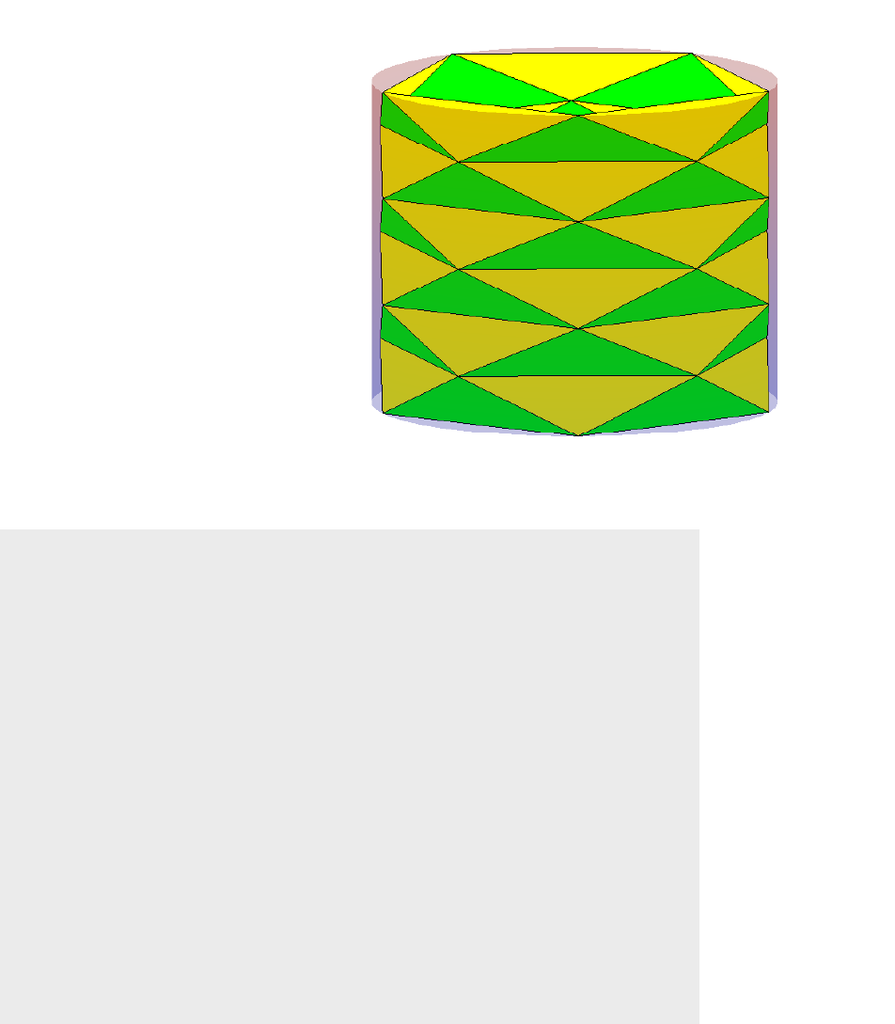

1.7 曲面逼近

割面逼近不一定有效

代码：

% 画圆柱

[X Y Z] = cylinder(1, 50);

Z = Z * 2;

surf(X, Y, Z); hold on;

shading interp

alpha(0.25);

% 画割面

n = 5; % 将圆 n 等分

m = 6; % 将高 m 等分

for i = 1 : m+1

for j = 1 : n + 1

11

X(i,j) = cos((2 * j + mod(i,2)) * pi / n);

Y(i,j) = sin((2 * j + mod(i,2)) * pi / n);

Z(i,j) = 2 * (i-1) / m;

end

end

for i = 1 : m

for j = 1 : n

x = [X(i,j) X(i,j+1) X(i+1,j+mod(i,2))];

y = [Y(i,j) Y(i,j+1) Y(i+1,j+mod(i,2))];

z = [Z(i,j) Z(i,j+1) Z(i+1,j+mod(i,2))];

fill3(x, y, z, ’g’);

end

end

for i = 2 : m + 1

for j = 1 : n

x = [X(i,j) X(i,j+1) X(i-1,j+mod(i,2))];

y = [Y(i,j) Y(i,j+1) Y(i-1,j+mod(i,2))];

z = [Z(i,j) Z(i,j+1) Z(i-1,j+mod(i,2))];

fill3(x, y, z, ’y’);

end

end

12